# Lecture 11: Binary choice and maximum likelihood

Economics 527: Econometric Methods

Vadim Marmer, UBC

# Binary choice

## Binary choice model

- Data: observations $(Y_i, X_i)$, $i = 1, \ldots, n$.
- Binary $Y_i$ indicates the choice:
  $$Y_i \in \{0, 1\}$$
- Examples:
  - in the labour force or not
  - went for a postgraduate degree or not
  - firm entered market $i$ or not
- Random (latent) utility from choice 1:
  $$V_i = X_i^\top \beta + \varepsilon_i$$
- Observed and unobserved:
  $$\begin{aligned}
  V_i &: \ \text{unobserved} \\
  X_i &: \ \text{observed characteristics} \\
  \varepsilon_i &: \ \text{unobserved}
  \end{aligned}$$
- Choice 1 when the utility is positive:
  $$\begin{aligned}
  Y_i &= \mathbf{1}(V_i > 0) \\
  &= \mathbf{1}(X_i^\top \beta + \varepsilon_i > 0)
  \end{aligned}$$
- $Y_i$ generated from a nonlinear model.

## Response probability

- **Assume:** $F$, the CDF of $\varepsilon_i$ given $X_i$, known:
  $$F(t) = \mathrm{P}(\varepsilon_i \le t \mid X_i = x) \quad \text{for all } x, t$$
- Substitute the model:
  $$\begin{aligned}
  \mathrm{P}(Y_i = 1 \mid X_i = x) &= \mathrm{P}(x^\top \beta + \varepsilon_i > 0 \mid X_i = x) \\
  &= \mathrm{P}(\varepsilon_i > -x^\top \beta \mid X_i = x) \\
  &= 1 - F(-x^\top \beta) \\
  \Longrightarrow\quad \mathrm{P}(Y_i = 1 \mid X_i) &= 1 - F(-X_i^\top \beta)
  \end{aligned}$$
- **Assume:** $F$ symmetric around zero:
  $$1 - F(-t) = F(t)$$
- Response probability with a symmetric $F$:
  $$\boxed{\ \mathrm{P}(Y_i = 1 \mid X_i) = F(X_i^\top \beta)\ }$$

# Linear probability model

## Uniform errors

- Suppose:
  $$\begin{aligned}
  & \varepsilon_i \mid X_i \sim \text{Uniform}(0, 1) \\
  \Longrightarrow\quad & F(t) = t, \quad t \in (0, 1)
  \end{aligned}$$
- Uniform CDF at $-X_i^\top \beta$:
  $$\begin{aligned}
  \mathrm{P}(Y_i = 1 \mid X_i) &= 1 - F(-X_i^\top \beta) \\
  &= 1 + X_i^\top \beta \\
  &= \underbrace{(\beta_1 + 1)}_{\text{intercept}} + X_{i,2}^\top \beta_2
  \end{aligned}$$
- **Assume:**
  $$0 < -X_i^\top \beta < 1$$
- $X_i$ includes an intercept:
  $$X_i = \begin{pmatrix} 1 \\ X_{i,2} \end{pmatrix}, \qquad \beta = \begin{pmatrix} \beta_1 \\ \beta_2 \end{pmatrix}$$
- Constant $1$: absorbed by the intercept.
- **Definition.** Linear probability model (LPM):
  $$\boxed{\ \mathrm{P}(Y_i = 1 \mid X_i) = X_i^\top \beta\ }$$

## Connection of LPM to regression

- Conditional mean of binary $Y_i$:
  $$\begin{aligned}
  \mathrm{E}\left[Y_i \mid X_i\right] &= 1 \cdot \mathrm{P}(Y_i = 1 \mid X_i) + 0 \cdot \mathrm{P}(Y_i = 0 \mid X_i) \\
  &= \mathrm{P}(Y_i = 1 \mid X_i)
  \end{aligned}$$
- LPM $\Longrightarrow$ linear regression of $Y_i$ on $X_i$:
  $$\mathrm{E}\left[Y_i \mid X_i\right] = \mathrm{P}(Y_i = 1 \mid X_i) = X_i^\top \beta$$

## LPM against an S-shaped CDF

- Scalar $x$: LPM, then CDF $F$:

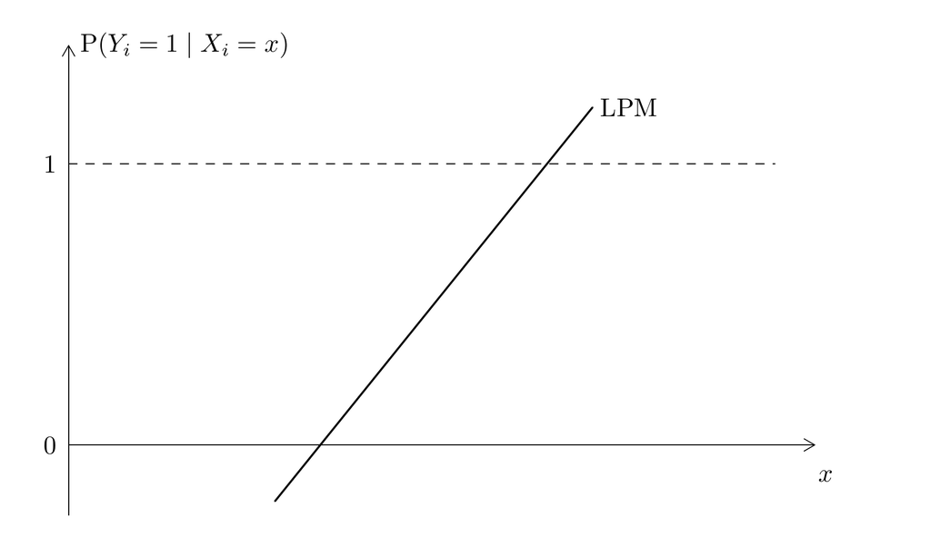

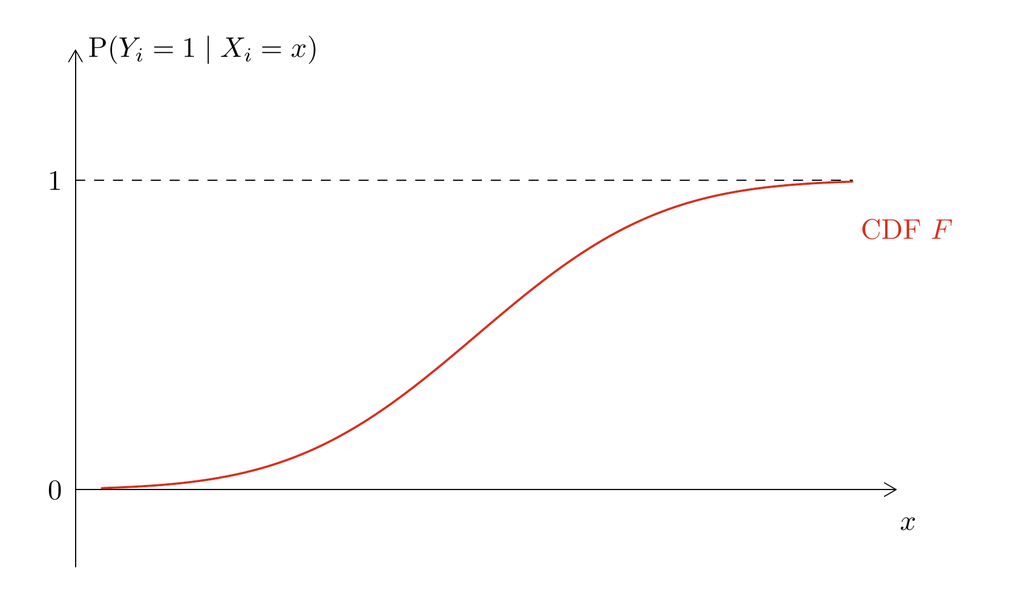

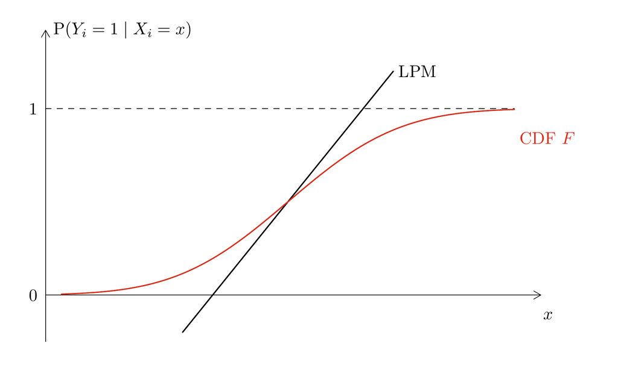

# Probit and logit

## Probit

- $\varepsilon_i \mid X_i \sim N(0, 1)$, CDF $\Phi$:
  $$\mathrm{P}(Y_i = 1 \mid X_i) = \boxed{\ \Phi(X_i^\top \beta)\ } \qquad (\Phi \ \text{symmetric around zero})$$

## Logit

- $\varepsilon_i \mid X_i$ logistic, CDF $\Lambda$:
  $$\begin{aligned}
  \Lambda(t) &= \frac{e^t}{1 + e^t} \\
  &= \frac{1}{e^{-t} + 1} \\
  &= \frac{1}{1 + \frac{1}{e^t}}
  \end{aligned}$$
- Probability of each choice:
  $$\begin{aligned}
  \mathrm{P}(Y_i = 1 \mid X_i) &= \frac{e^{X_i^\top \beta}}{1 + e^{X_i^\top \beta}} \\
  \mathrm{P}(Y_i = 0 \mid X_i) &= 1 - \frac{e^{X_i^\top \beta}}{1 + e^{X_i^\top \beta}} \\
  &= \frac{1}{1 + e^{X_i^\top \beta}}
  \end{aligned}$$
- Odds ratio:
  $$\frac{\mathrm{P}(Y_i = 1 \mid X_i)}{\mathrm{P}(Y_i = 0 \mid X_i)} = e^{X_i^\top \beta}$$
- Log odds ratio:
  $$\boxed{\ \log \frac{\mathrm{P}(Y_i = 1 \mid X_i)}{\mathrm{P}(Y_i = 0 \mid X_i)} = X_i^\top \beta\ }$$

# Identification

## Scale of $\beta$ and $\varepsilon_i$

- Suppose $\varepsilon_i \mid X_i \sim N(0, \sigma^2)$.
- Rescaled coefficients and errors:
  $$\beta^* = \frac{\beta}{\sigma}, \qquad \varepsilon_i^* = \frac{\varepsilon_i}{\sigma}, \qquad \varepsilon_i^* \mid X_i \sim N(0, 1)$$
- Divide by $\sigma > 0$ inside the indicator:
  $$\begin{aligned}
  Y_i &= \mathbf{1}(X_i^\top \beta + \varepsilon_i > 0) \\
  &= \mathbf{1}\Big(X_i^\top \frac{\beta}{\sigma} + \frac{\varepsilon_i}{\sigma} > 0\Big) \\
  &= \mathbf{1}(X_i^\top \beta^* + \varepsilon_i^* > 0)
  \end{aligned}$$
- Example with scalar $X_{i,2}$, same distribution of $Y_i$ given $X_i$:
  $$\begin{aligned}
  \text{1)} \quad & Y_i = \mathbf{1}(1 + X_{i,2} + \varepsilon_i > 0), \qquad \varepsilon_i \mid X_i \sim N(0, 4) \\
  \text{2)} \quad & Y_i = \mathbf{1}\big(\tfrac{1}{2} + \tfrac{1}{2} X_{i,2} + \varepsilon_i > 0\big), \qquad \varepsilon_i \mid X_i \sim N(0, 1)
  \end{aligned}$$
- Only $\beta / \sigma$ can be identified.

## Location of $\varepsilon_i$ and the intercept

- Suppose $\varepsilon_i \mid X_i \sim N(\mu, \sigma^2)$:
  $$\begin{aligned}
  \mathrm{P}(Y_i = 1 \mid X_i) &= \mathrm{P}(X_i^\top \beta + \varepsilon_i > 0 \mid X_i) \\
  &= \mathrm{P}(\varepsilon_i > -X_i^\top \beta \mid X_i) \\
  &= \mathrm{P}\Big(\frac{\varepsilon_i - \mu}{\sigma} > \frac{-X_i^\top \beta - \mu}{\sigma} \ \Big|\ X_i\Big) \\
  &= \Phi\Big(\frac{X_i^\top \beta + \mu}{\sigma}\Big) \qquad \Big(\frac{\varepsilon_i - \mu}{\sigma} \ \Big|\ X_i \sim N(0, 1)\Big)
  \end{aligned}$$
- Intercept, $X_i = (1, X_{i,2}^\top)^\top$, $\beta = (\beta_1, \beta_2^\top)^\top$:
  $$\frac{X_i^\top \beta + \mu}{\sigma} = \underbrace{\frac{\beta_1 + \mu}{\sigma}}_{\text{intercept}} + X_{i,2}^\top \frac{\beta_2}{\sigma}$$
- $\mu$: absorbed by the intercept.

## Identification of probit

- $\mathrm{P}(Y_i = 1 \mid X_i = x)$: can be estimated from the data.
- Invert $\Phi$:
  $$\begin{aligned}
  & \mathrm{P}(Y_i = 1 \mid X_i = x) = \Phi(x^\top \beta) \\
  \Longleftrightarrow\quad & \Phi^{-1}\big(\mathrm{P}(Y_i = 1 \mid X_i = x)\big) = x^\top \beta, \qquad \beta \in \mathbb{R}^k
  \end{aligned}$$
- Quantile of $N(0, 1)$, with $\Phi^{-1}(\tau) = z_\tau$:
  $$z(x) = \Phi^{-1}\big(\mathrm{P}(Y_i = 1 \mid X_i = x)\big) = z_{\mathrm{P}(Y_i = 1 \mid X_i = x)}$$
- Pick values $x_1, \ldots, x_k$ of $X_i$: $k \times 1$, linearly independent:
  $$\begin{aligned}
  \underbrace{\begin{pmatrix} z(x_1) \\ \vdots \\ z(x_k) \end{pmatrix}}_{k \times 1} &= \underbrace{\begin{pmatrix} \overset{1 \times k}{x_1^\top} \\ \vdots \\ x_k^\top \end{pmatrix}}_{k \times k} \beta \\
  \Longrightarrow\quad \beta &= \begin{pmatrix} x_1^\top \\ \vdots \\ x_k^\top \end{pmatrix}^{-1} \begin{pmatrix} z(x_1) \\ \vdots \\ z(x_k) \end{pmatrix}
  \end{aligned}$$
- $\beta$: identified.

## Identification of logit

- Log odds ratio at $X_i = x$, identified from the data:
  $$r(x) = \log \frac{\mathrm{P}(Y_i = 1 \mid X_i = x)}{\mathrm{P}(Y_i = 0 \mid X_i = x)} = x^\top \beta$$
- Same steps, $r(x)$ in place of $z(x)$:
  $$\beta = \begin{pmatrix} x_1^\top \\ \vdots \\ x_k^\top \end{pmatrix}^{-1} \begin{pmatrix} r(x_1) \\ \vdots \\ r(x_k) \end{pmatrix}$$

## Example: Walmart and town population

- $\text{Walmart}_i = 1$: a Walmart in town $i$.
- Logit given the population of town $i$:
  $$\mathrm{P}(\text{Walmart}_i = 1 \mid \text{Population}_i = x) = \frac{e^{\beta_1 + \beta_2 x}}{1 + e^{\beta_1 + \beta_2 x}}$$
- Log odds ratio, identified from the data:
  $$r(x) = \log \frac{\mathrm{P}(\text{Walmart}_i = 1 \mid \text{Population}_i = x)}{\mathrm{P}(\text{Walmart}_i = 0 \mid \text{Population}_i = x)} = \beta_1 + \beta_2 x$$
- Two town populations, $x = 10{,}000$ and $x = 25{,}000$:
  $$\begin{aligned}
  & r(10{,}000) = \beta_1 + \beta_2 \cdot 10{,}000 \\
  & r(25{,}000) = \beta_1 + \beta_2 \cdot 25{,}000 \\
  \Longleftrightarrow\quad & \begin{bmatrix} r(10{,}000) \\ r(25{,}000) \end{bmatrix} = \begin{bmatrix} 1 & 10{,}000 \\ 1 & 25{,}000 \end{bmatrix} \begin{bmatrix} \beta_1 \\ \beta_2 \end{bmatrix} \\
  \Longrightarrow\quad & \begin{bmatrix} \beta_1 \\ \beta_2 \end{bmatrix} = \begin{bmatrix} 1 & 10{,}000 \\ 1 & 25{,}000 \end{bmatrix}^{-1} \begin{bmatrix} r(10{,}000) \\ r(25{,}000) \end{bmatrix}
  \end{aligned}$$

# Marginal effects

## Marginal effects in the linear model, probit and logit

- LPM:
  $$\begin{aligned}
  & \mathrm{E}\left[Y_i \mid X_i = x\right] = \mathrm{P}(Y_i = 1 \mid X_i = x) = x^\top \beta \\
  \Longrightarrow\quad & \beta_j = \frac{\partial\, \mathrm{P}(Y_i = 1 \mid X_i = x)}{\partial x_j}
  \end{aligned}$$
- $\beta_j$: the same at every $x$.
- Probit and logit, $f$: PDF of $F$:
  $$\begin{aligned}
  & \mathrm{P}(Y_i = 1 \mid X_i = x) = F(x^\top \beta) \\
  \Longrightarrow\quad & \frac{\partial\, \mathrm{P}(Y_i = 1 \mid X_i = x)}{\partial x_j} = f(x^\top \beta)\, \beta_j
  \end{aligned}$$
- $f(x^\top \beta)\, \beta_j$: changes with $x$.

## Average marginal effect (AME)

- **Definition.** Marginal effect averaged over $X_i$:
  $$\begin{aligned}
  \mathrm{AME}_j &= \mathrm{E}\left[f(X_i^\top \beta)\, \beta_j\right] \\
  &= \mathrm{E}\left[f(X_i^\top \beta)\right]\, \beta_j
  \end{aligned}$$

# Maximum likelihood estimator (MLE)

## Bernoulli trials

- Consider a version with only $Y_i$: no varying regressors $X_i$.
- Data $Y_1, \ldots, Y_n \in \{0, 1\}$, iid:
  $$\begin{aligned}
  \mathrm{P}(Y_i = 1) &= \theta_0 \in (0, 1) \\
  \mathrm{P}(Y_i = 0) &= 1 - \theta_0
  \end{aligned}$$
- $\theta_0$: true value of $\theta$.
- PMF, $y \in \{0, 1\}$:
  $$\mathrm{P}(Y_i = y) = \theta_0^{\,y} (1 - \theta_0)^{1 - y}$$
- A possible sample, one of $2^n$:
  $$y_1, \ldots, y_n, \qquad y_i \in \{0, 1\}$$
- Probability of the observed sample:
  $$\begin{aligned}
  \mathrm{P}(Y_1 = y_1, \ldots, Y_n = y_n) &= \prod_{i=1}^n \mathrm{P}(Y_i = y_i) \qquad \text{(independence)} \\
  &= \prod_{i=1}^n \theta_0^{\,y_i} (1 - \theta_0)^{1 - y_i} \\
  &= \theta_0^{\sum_i y_i} (1 - \theta_0)^{n - \sum_i y_i}
  \end{aligned}$$

## Likelihood function and the MLE

- Observed sample probability as a likelihood function of $\theta$:
  $$L_n(\theta) = \theta^{\sum_i Y_i} (1 - \theta)^{n - \sum_i Y_i}$$
- **Definition.** MLE:
  $$\begin{aligned}
  \hat\theta &= \underset{\theta}{\arg\max}\ L_n(\theta) \\
  &= \underset{\theta}{\arg\max}\ \frac{1}{n} \log L_n(\theta)
  \end{aligned}$$
- Average log likelihood, with $\bar Y = \frac{1}{n} \sum_{i=1}^n Y_i$:
  $$\begin{aligned}
  \frac{1}{n} \log L_n(\theta) &= \frac{1}{n} \sum_{i=1}^n Y_i \log \theta + \frac{1}{n} \Big(n - \sum_{i=1}^n Y_i\Big) \log(1 - \theta) \\
  &= \bar Y \log \theta + (1 - \bar Y) \log(1 - \theta)
  \end{aligned}$$

## MLE in Bernoulli trials

- First-order condition:
  $$\frac{\partial}{\partial \theta} \Big(\frac{1}{n} \log L_n(\theta)\Big) = \frac{\bar Y}{\theta} - \frac{1 - \bar Y}{1 - \theta}$$
- $\hat\theta$ solves:
  $$\begin{aligned}
  & \frac{\bar Y}{\hat\theta} - \frac{1 - \bar Y}{1 - \hat\theta} = 0 \\
  \Longrightarrow\quad & \boxed{\ \hat\theta = \bar Y\ }
  \end{aligned}$$
- Weak LLN for $\bar Y$:
  $$\begin{aligned}
  \hat\theta = \bar Y &\to_p \mathrm{E}\left[Y_i\right] \\
  &= 1 \cdot \theta_0 + 0 \cdot (1 - \theta_0) \\
  &= \theta_0
  \end{aligned}$$

## Normal regression model

- Normal regression with iid observations $(Y_i, X_i)$:
  $$\begin{aligned}
  Y_i &= X_i^\top \beta_0 + U_i \\
  U_i \mid X_i &\sim N(0, \sigma_0^2)
  \end{aligned}$$
- PDF of $U_i$ given $X_i$, at $u$:
  $$\frac{1}{\sqrt{2\pi\sigma_0^2}} \exp\Big(-\frac{u^2}{2\sigma_0^2}\Big)$$
- Distribution of $Y_i$ given $X_i = x$:
  $$Y_i \mid X_i = x \sim N(x^\top \beta_0,\ \sigma_0^2)$$
- PDF of $Y_i$ at $y$ given $X_i = x$, with $u = y - x^\top \beta_0$:
  $$\frac{1}{\sqrt{2\pi\sigma_0^2}} \exp\Big(-\frac{(y - x^\top \beta_0)^2}{2\sigma_0^2}\Big)$$

## MLE in the normal regression

- Conditional likelihood:
  $$\begin{aligned}
  L_n(\beta, \sigma^2) &= \prod_{i=1}^n \frac{1}{\sqrt{2\pi\sigma^2}} \exp\Big(-\frac{(Y_i - X_i^\top \beta)^2}{2\sigma^2}\Big) \\
  &= \Big(\frac{1}{\sqrt{2\pi\sigma^2}}\Big)^n \exp\Big(-\frac{\sum_{i=1}^n (Y_i - X_i^\top \beta)^2}{2\sigma^2}\Big)
  \end{aligned}$$
- Average conditional log likelihood:
  $$\begin{aligned}
  \frac{1}{n} \log L_n(\beta, \sigma^2) &= \log \frac{1}{\sqrt{2\pi\sigma^2}} - \frac{1}{2\sigma^2}\, \frac{1}{n} \sum_{i=1}^n (Y_i - X_i^\top \beta)^2 \\
  &= \log\big((2\pi\sigma^2)^{-1/2}\big) - \frac{1}{2\sigma^2}\, \frac{1}{n} \sum_{i=1}^n (Y_i - X_i^\top \beta)^2 \\
  &= -\frac{1}{2} \log(2\pi\sigma^2) - \frac{1}{2\sigma^2}\, \frac{1}{n} \sum_{i=1}^n (Y_i - X_i^\top \beta)^2
  \end{aligned}$$
- MLE of $\beta$:
  $$\begin{aligned}
  \hat\beta^{MLE} &= \underset{\beta}{\arg\max}\ \frac{1}{n} \log L_n(\beta, \sigma^2) \\
  &= \underset{\beta}{\arg\max}\ \Big(-\frac{1}{n} \sum_{i=1}^n (Y_i - X_i^\top \beta)^2\Big) \\
  &= \underset{\beta}{\arg\min}\ \frac{1}{n} \sum_{i=1}^n (Y_i - X_i^\top \beta)^2 \\
  &= \hat\beta^{OLS}
  \end{aligned}$$

## Conditional likelihood for probit and logit

- iid observations $(Y_i, X_i)$:
  $$\{(Y_i, X_i) : i = 1, \ldots, n\}$$
- Probit and logit response probability:
  $$\mathrm{P}(Y_i = 1 \mid X_i = x) = \underbrace{F(x^\top \beta_0)}_{=\, \theta_0(x)}$$
- Conditional PMF, $y \in \{0, 1\}$:
  $$\mathrm{P}(Y_i = y \mid X_i) = F(X_i^\top \beta_0)^y \big(1 - F(X_i^\top \beta_0)\big)^{1 - y}$$
- Probability of the observed outcomes given the regressors:
  $$\begin{aligned}
  & \mathrm{P}(Y_1 = y_1, \ldots, Y_n = y_n \mid X_1, \ldots, X_n) \\
  &= \prod_{i=1}^n \mathrm{P}(Y_i = y_i \mid X_i) \\
  &= \prod_{i=1}^n F(X_i^\top \beta_0)^{y_i} \big(1 - F(X_i^\top \beta_0)\big)^{1 - y_i}
  \end{aligned}$$

## Conditional log likelihood and grid search

- Average conditional log likelihood:
  $$\frac{1}{n} \log L_n(\beta) = \frac{1}{n} \sum_{i=1}^n \Big\{Y_i \log F(X_i^\top \beta) + (1 - Y_i) \log\big(1 - F(X_i^\top \beta)\big)\Big\}$$
- MLE of $\beta$:
  $$\hat\beta^{MLE} = \underset{\beta \in \mathbb{R}^k}{\arg\max}\ \frac{1}{n} \log L_n(\beta)$$
- Grid search, scalar $\beta$:

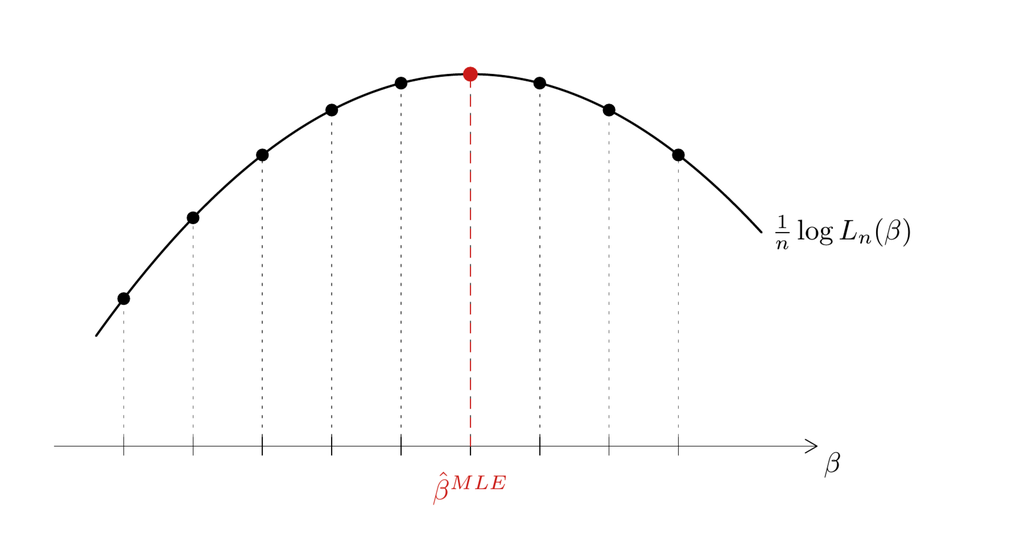

# Consistency of the MLE

## General setup

- Data $\{W_i : i = 1, \ldots, n\}$, PDF or PMF $f(w, \theta_0)$:
  $$W_i \overset{\text{iid}}{\sim} f(w, \theta_0), \qquad \theta_0 \in \mathbb{R}^k: \ \text{true value}$$
- **Assume:** common support $\{w : f(w, \theta) > 0\}$ for all $\theta$.
- **Assume:** $\mathrm{E}\left[|\log f(W_i, \theta_0)|\right] < \infty$.
- Logit: $W_i = (Y_i, X_i^\top)^\top$ and $\theta = \beta$.
- $f$: conditional PMF of $Y_i$ given $X_i$:
  $$f(w, \theta_0) = \Lambda(x^\top \theta_0)^y \big(1 - \Lambda(x^\top \theta_0)\big)^{1 - y}, \qquad w = (y, x^\top)^\top, \quad y \in \{0, 1\}$$
- MLE, maximizer of the average log likelihood:
  $$\hat\theta = \underset{\theta}{\arg\max}\ \frac{1}{n} \sum_{i=1}^n \log f(W_i, \theta)$$
- To show (consistency):
  $$\hat\theta \to_p \theta_0$$

## Consistency argument

- $\theta^*$: unique maximizer of $\mathrm{E}\left[\log f(W_i, \theta)\right]$.
- Weak LLN for each $\theta$, then maximize both sides, under regularity conditions:
  $$\begin{array}{ccc}
  \dfrac{1}{n} \displaystyle\sum_{i=1}^n \log f(W_i, \theta) & \to_p & \mathrm{E}\left[\log f(W_i, \theta)\right] \\[1ex]
  \Big\downarrow \ \arg\max & & \Big\downarrow \ \arg\max \\[1ex]
  \hat\theta & \to_p & \theta^*
  \end{array}$$
- Consistency if the population maximizer is $\theta_0$:
  $$\boxed{\ \theta^* = \theta_0 \quad \Longrightarrow \quad \hat\theta \to_p \theta_0\ }$$

## Jensen’s inequality and the population log likelihood

- We will use Jensen’s inequality, $h$ concave:
  $$\mathrm{E}\left[h(Z)\right] \le h\big(\mathrm{E}\left[Z\right]\big)$$
- **Claim.** For all $\theta$:
  $$\mathrm{E}\left[\log f(W_i, \theta)\right] \le \mathrm{E}\left[\log f(W_i, \theta_0)\right]$$
- Proof, $f(w, \theta_0)$: the true PDF of $W_i$:
  $$\begin{aligned}
  & \mathrm{E}\left[\log f(W_i, \theta)\right] - \mathrm{E}\left[\log f(W_i, \theta_0)\right] \\
  &= \mathrm{E}\left[\log f(W_i, \theta) - \log f(W_i, \theta_0)\right] \\
  &= \mathrm{E}\left[\log \frac{f(W_i, \theta)}{f(W_i, \theta_0)}\right] \\
  &\le \log \mathrm{E}\left[\frac{f(W_i, \theta)}{f(W_i, \theta_0)}\right] \qquad \text{(Jensen's inequality, $\log$ concave)} \\
  &= \log \int \frac{f(w, \theta)}{{\color{red} f(w, \theta_0)}}\, {\color{red} f(w, \theta_0)}\, dw \\
  &= \log \underbrace{\int f(w, \theta)\, dw}_{=\, 1} \\
  &= 0
  \end{aligned}$$

## Strict inequality and identification

- Suppose $\theta \ne \theta_0$, $\log$ strictly concave:
  $$\mathrm{E}\left[\log \frac{f(W_i, \theta)}{f(W_i, \theta_0)}\right] < \log \mathrm{E}\left[\frac{f(W_i, \theta)}{f(W_i, \theta_0)}\right]$$
- Unless the ratio is constant with probability one:
  $$\begin{aligned}
  & \frac{f(W_i, \theta)}{f(W_i, \theta_0)} = \text{const} \\
  \Longleftrightarrow\quad & f(W_i, \theta) = \underbrace{\text{const}}_{=\, 1} \cdot f(W_i, \theta_0)
  \end{aligned}$$
- **Assume** (identification), for all $\theta \ne \theta_0$:
  $$\mathrm{P}\big(f(W_i, \theta) \ne f(W_i, \theta_0)\big) > 0$$
- Hence:
  $$\begin{aligned}
  & \mathrm{E}\left[\log f(W_i, \theta)\right] < \mathrm{E}\left[\log f(W_i, \theta_0)\right] \quad \text{for all } \theta \ne \theta_0 \\
  \Longrightarrow\quad & \theta^* = \theta_0 \\
  \Longrightarrow\quad & \hat\theta \to_p \theta_0
  \end{aligned}$$

## Identification in the logit

- Logit:
  $$f(W_i, \theta) = \Lambda(X_i^\top \theta)^{Y_i} \big(1 - \Lambda(X_i^\top \theta)\big)^{1 - Y_i}$$
- $\Lambda$ strictly increasing:
  $$\Lambda(u_1) = \Lambda(u_2) \quad \Longleftrightarrow \quad u_1 = u_2$$
- Suppose $\theta_1 \ne \theta_0$:
  $$\begin{aligned}
  f(W_i, \theta_1) = f(W_i, \theta_0) \quad &\Longleftrightarrow \quad X_i^\top \theta_1 = X_i^\top \theta_0 \\
  &\Longleftrightarrow \quad X_i^\top \underbrace{(\theta_1 - \theta_0)}_{=\, a} = 0
  \end{aligned}$$
- To rule out $X_i^\top a = 0$ with probability one, **assume:** $\mathrm{E}\left[X_i X_i^\top\right]$ p.d.:
  $$\begin{aligned}
  a \ne 0 \quad &\Longrightarrow \quad \mathrm{P}(X_i^\top a \ne 0) > 0 \\
  &\Longrightarrow \quad \mathrm{P}\big(f(W_i, \theta_1) \ne f(W_i, \theta_0)\big) > 0
  \end{aligned}$$

# Asymptotic normality and standard errors

## Gradient and Hessian

- $h : \mathbb{R}^k \to \mathbb{R}$, gradient:
  $$\underset{k \times 1}{\frac{\partial h}{\partial \theta}} = \begin{bmatrix} \dfrac{\partial h}{\partial \theta_1} \\ \vdots \\ \dfrac{\partial h}{\partial \theta_k} \end{bmatrix}$$
- Hessian:
  $$\underset{k \times k}{\frac{\partial^2 h}{\underset{k \times 1}{\partial \theta}\, \underset{1 \times k}{\partial \theta^\top}}} = \begin{bmatrix} \dfrac{\partial^2 h}{\partial \theta_1 \partial \theta_1} & \cdots & \dfrac{\partial^2 h}{\partial \theta_1 \partial \theta_k} \\ \vdots & & \vdots \\ \dfrac{\partial^2 h}{\partial \theta_k \partial \theta_1} & \cdots & \dfrac{\partial^2 h}{\partial \theta_k \partial \theta_k} \end{bmatrix}$$
- Score of observation $i$, gradient of its log likelihood:
  $$\frac{\partial}{\partial \theta} \log f(W_i, \theta)$$

## First-order condition and expansion

- We will use the expansion of $h$ around $\theta_0$:
  $$h(\hat\theta) \approx h(\theta_0) + \frac{\partial h(\theta_0)}{\partial \theta^\top} (\hat\theta - \theta_0)$$
- First-order condition for $\hat\theta$, each element expanded around $\theta_0$:
  $$\begin{aligned}
  \underset{k \times 1}{0} &= \frac{\partial}{\partial \theta} \Big[\frac{1}{n} \sum_{i=1}^n \log f(W_i, \hat\theta)\Big] \\
  &= \frac{1}{n} \sum_{i=1}^n \frac{\partial}{\partial \theta} \log f(W_i, \hat\theta) \\
  &\approx \frac{1}{n} \sum_{i=1}^n \underbrace{\frac{\partial}{\partial \theta} \log f(W_i, \theta_0)}_{k \times 1} + \underbrace{\Big[\frac{1}{n} \sum_{i=1}^n \frac{\partial^2 \log f(W_i, \theta_0)}{\partial \theta\, \partial \theta^\top}\Big]}_{k \times k} \underbrace{(\hat\theta - \theta_0)}_{k \times 1}
  \end{aligned}$$
- OLS normal equations:
  $$\begin{aligned}
  0 &= \frac{1}{n} \sum_{i=1}^n X_i \hat U_i \\
  &= \frac{1}{n} \sum_{i=1}^n X_i (Y_i - X_i^\top \hat\beta^{OLS}) \\
  &= \frac{1}{n} \sum_{i=1}^n X_i \big(U_i - X_i^\top (\hat\beta^{OLS} - \beta_0)\big)
  \end{aligned}$$

## Solving for $\sqrt{n}(\hat\theta - \theta_0)$

- Solve for $\hat\theta - \theta_0$, then multiply by $\sqrt{n}$:
  $$\begin{aligned}
  & \Big[\frac{1}{n} \sum_{i=1}^n \frac{\partial^2 \log f(W_i, \theta_0)}{\partial \theta\, \partial \theta^\top}\Big] (\hat\theta - \theta_0) \approx -\frac{1}{n} \sum_{i=1}^n \frac{\partial}{\partial \theta} \log f(W_i, \theta_0) \\
  \Longrightarrow\quad & \hat\theta - \theta_0 \approx -\Big[\frac{1}{n} \sum_{i=1}^n \frac{\partial^2 \log f(W_i, \theta_0)}{\partial \theta\, \partial \theta^\top}\Big]^{-1} \frac{1}{n} \sum_{i=1}^n \frac{\partial}{\partial \theta} \log f(W_i, \theta_0) \\
  \Longrightarrow\quad & \sqrt{n}(\hat\theta - \theta_0) \\
  &\qquad \approx -\Big[\frac{1}{n} \sum_{i=1}^n \frac{\partial^2 \log f(W_i, \theta_0)}{\partial \theta\, \partial \theta^\top}\Big]^{-1} \frac{1}{\sqrt{n}} \sum_{i=1}^n \frac{\partial}{\partial \theta} \log f(W_i, \theta_0)
  \end{aligned}$$
- Same form for the scaled OLS estimation error:
  $$\sqrt{n}(\hat\beta^{OLS} - \beta_0) = \Big(\frac{1}{n} \sum_{i=1}^n X_i X_i^\top\Big)^{-1} \frac{1}{\sqrt{n}} \sum_{i=1}^n X_i U_i$$

## Average Hessian and scaled score

- Weak LLN for the average Hessian, limit assumed negative definite:
  $$\frac{1}{n} \sum_{i=1}^n \frac{\partial^2 \log f(W_i, \theta_0)}{\partial \theta\, \partial \theta^\top} \to_p \mathrm{E}\left[\frac{\partial^2 \log f(W_i, \theta_0)}{\partial \theta\, \partial \theta^\top}\right]$$
- Variance of the score:
  $$\begin{aligned}
  \Omega_0 &= \mathrm{Var}\left(\frac{\partial}{\partial \theta} \log f(W_i, \theta_0)\right) \\
  &= \mathrm{E}\left[\frac{\partial}{\partial \theta} \log f(W_i, \theta_0)\, \frac{\partial}{\partial \theta^\top} \log f(W_i, \theta_0)\right]
  \end{aligned}$$
- Second-moment form of $\Omega_0$ and the CLT need:
  $$\mathrm{E}\left[\frac{\partial}{\partial \theta} \log f(W_i, \theta_0)\right] = 0$$
- CLT for the scaled score:
  $$\frac{1}{\sqrt{n}} \sum_{i=1}^n \frac{\partial}{\partial \theta} \log f(W_i, \theta_0) \to_d N(0, \Omega_0)$$

## Mean of the score

- **Assume:** $\frac{\partial}{\partial \theta}$ and $\int$ interchange.
- Population first-order condition, $\theta_0 = \arg\max_\theta \mathrm{E}\left[\log f(W_i, \theta)\right]$:
  $$\begin{aligned}
  \mathrm{E}\left[\frac{\partial}{\partial \theta} \log f(W_i, \theta_0)\right] &= \frac{\partial}{\partial \theta} \mathrm{E}\left[\log f(W_i, \theta)\right] \Big|_{\theta = \theta_0} \\
  &= 0
  \end{aligned}$$
- A more direct argument:
  $$\begin{aligned}
  \mathrm{E}\left[\frac{\partial}{\partial \theta} \log f(W_i, \theta_0)\right] &= \mathrm{E}\left[\frac{\partial f(W_i, \theta_0) / \partial \theta}{f(W_i, \theta_0)}\right] \\
  &= \int \frac{\partial f(w, \theta_0) / \partial \theta}{{\color{red} f(w, \theta_0)}} \cdot {\color{red} f(w, \theta_0)}\, dw \\
  &= \int \frac{\partial f(w, \theta_0)}{\partial \theta}\, dw \\
  &= \frac{\partial}{\partial \theta} \underbrace{\int f(w, \theta_0)\, dw}_{=\, 1} \\
  &= 0
  \end{aligned}$$

## Sandwich form

- Weak LLN for the average Hessian, CLT for the scaled score:
  $$\begin{aligned}
  \sqrt{n}(\hat\theta - \theta_0) &\approx -\Big[\frac{1}{n} \sum_{i=1}^n \frac{\partial^2 \log f(W_i, \theta_0)}{\partial \theta\, \partial \theta^\top}\Big]^{-1} \frac{1}{\sqrt{n}} \sum_{i=1}^n \frac{\partial}{\partial \theta} \log f(W_i, \theta_0) \\
  &\to_d -\Big(\mathrm{E}\left[\frac{\partial^2 \log f(W_i, \theta_0)}{\partial \theta\, \partial \theta^\top}\right]\Big)^{-1} N(0, \Omega_0)
  \end{aligned}$$
- Asymptotic variance, the Hessian symmetric:
  $$\mathrm{AsyVar}(\hat\theta) = \Big(\mathrm{E}\left[\frac{\partial^2 \log f(W_i, \theta_0)}{\partial \theta\, \partial \theta^\top}\right]\Big)^{-1} \Omega_0 \Big(\mathrm{E}\left[\frac{\partial^2 \log f(W_i, \theta_0)}{\partial \theta\, \partial \theta^\top}\right]\Big)^{-1}$$

## Information matrix equality

- **Claim.**
  $$\mathrm{E}\left[\frac{\partial^2 \log f(W_i, \theta_0)}{\partial \theta\, \partial \theta^\top}\right] = -\Omega_0$$
- We will use:
  $$\begin{aligned}
  \mathrm{E}\left[\frac{\partial^2 f(W_i, \theta_0) / \partial \theta\, \partial \theta^\top}{f(W_i, \theta_0)}\right] &= \int \frac{\partial^2 f(w, \theta_0)}{\partial \theta\, \partial \theta^\top}\, \frac{1}{{\color{red} f(w, \theta_0)}} \cdot {\color{red} f(w, \theta_0)}\, dw \\
  &= \frac{\partial^2}{\partial \theta\, \partial \theta^\top} \underbrace{\int f(w, \theta_0)\, dw}_{=\, 1} \\
  &= 0
  \end{aligned}$$
- Differentiate the score:
  $$\begin{aligned}
  & \mathrm{E}\left[\frac{\partial^2 \log f(W_i, \theta_0)}{\partial \theta\, \partial \theta^\top}\right] \\
  &= \mathrm{E}\left[\frac{\partial}{\partial \theta^\top}\, \frac{\partial}{\partial \theta} \log f(W_i, \theta_0)\right] \\
  &= \mathrm{E}\left[\frac{\partial}{\partial \theta^\top}\, \frac{\partial f(W_i, \theta_0) / \partial \theta}{f(W_i, \theta_0)}\right] \\
  &= \mathrm{E}\left[\frac{\partial^2 f(W_i, \theta_0) / \partial \theta\, \partial \theta^\top}{f(W_i, \theta_0)} - \underbrace{\frac{\partial f(W_i, \theta_0) / \partial \theta}{f(W_i, \theta_0)}}_{\frac{\partial}{\partial \theta} \log f(W_i, \theta_0)}\, \underbrace{\frac{\partial f(W_i, \theta_0) / \partial \theta^\top}{f(W_i, \theta_0)}}_{\frac{\partial}{\partial \theta^\top} \log f(W_i, \theta_0)}\right] \\
  &= \underbrace{\mathrm{E}\left[\frac{\partial^2 f(W_i, \theta_0) / \partial \theta\, \partial \theta^\top}{f(W_i, \theta_0)}\right]}_{=\, 0} - \Omega_0 \\
  &= \boxed{\ -\Omega_0\ }
  \end{aligned}$$

## Information matrix and asymptotic variance

- **Definition.** Information matrix:
  $$I(\theta_0) = -\mathrm{E}\left[\frac{\partial^2 \log f(W_i, \theta_0)}{\partial \theta\, \partial \theta^\top}\right]$$
- $I(\theta_0)$: symmetric, p.d.
- Substitute $\Omega_0$ from the information matrix equality:
  $$\begin{aligned}
  & \mathrm{AsyVar}(\hat\theta) \\
  &= \Big(\mathrm{E}\left[\frac{\partial^2 \log f(W_i, \theta_0)}{\partial \theta\, \partial \theta^\top}\right]\Big)^{-1} \underbrace{\Omega_0}_{=\, -\mathrm{E}\left[\frac{\partial^2 \log f(W_i, \theta_0)}{\partial \theta\, \partial \theta^\top}\right]} \Big(\mathrm{E}\left[\frac{\partial^2 \log f(W_i, \theta_0)}{\partial \theta\, \partial \theta^\top}\right]\Big)^{-1} \\
  &= -\Big(\mathrm{E}\left[\frac{\partial^2 \log f(W_i, \theta_0)}{\partial \theta\, \partial \theta^\top}\right]\Big)^{-1} \\
  &= \Big(-\mathrm{E}\left[\frac{\partial^2 \log f(W_i, \theta_0)}{\partial \theta\, \partial \theta^\top}\right]\Big)^{-1} \\
  &= I(\theta_0)^{-1}
  \end{aligned}$$
- Asymptotic distribution of the MLE:
  $$\boxed{\ \sqrt{n}(\hat\theta - \theta_0) \to_d N\big(0,\ I(\theta_0)^{-1}\big)\ }$$

## Standard errors

- $\hat\theta_j$, $\theta_{0,j}$: element $j$ of $\hat\theta$, $\theta_0$.
- Estimator of $\Omega_0$:
  $$\hat\Omega = \frac{1}{n} \sum_{i=1}^n \frac{\partial \log f(W_i, \hat\theta)}{\partial \theta}\, \frac{\partial \log f(W_i, \hat\theta)}{\partial \theta^\top}$$
- Standard error of $\hat\theta_j$, from the average Hessian at $\hat\theta$:
  $$\text{std. err}(\hat\theta_j) = \sqrt{\frac{\Big(\Big[-\frac{1}{n} \sum_{i=1}^n \frac{\partial^2 \log f(W_i, \hat\theta)}{\partial \theta\, \partial \theta^\top}\Big]^{-1}\Big)_{jj}}{n}}$$
- Or from $\hat\Omega$:
  $$\text{std. err}(\hat\theta_j) = \sqrt{\frac{\big(\hat\Omega^{-1}\big)_{jj}}{n}}$$
- $t$ test of $H_0: \theta_{0,j} = c$ vs $H_1: \theta_{0,j} \ne c$: $|\hat\theta_j - c| / \text{std. err}(\hat\theta_j) > z_{1-\alpha/2}$ $\Longrightarrow$ reject.

# Estimated average marginal effect

## AME estimator

- AME estimator from $\hat\beta$ and known $f$:
  $$\widehat{\mathrm{AME}}_j = \frac{1}{n} \sum_{i=1}^n f(X_i^\top \hat\beta)\, \hat\beta_j$$

# Stein’s lemma and LPM slopes

## Normal regressors and Stein’s lemma

- $\mathrm{E}\left[Y_i \mid X_i\right] = g(X_{i,2})$: nonlinear, unknown.
- AME, with $g'(x) = \partial g(x) / \partial x$:
  $$\mathrm{AME} = \mathrm{E}\left[g'(X_{i,2})\right]$$
- Probit and logit:
  $$\begin{aligned}
  g(x) &= F(\beta_1 + x^\top \beta_2) \\
  g'(x) &= f(\beta_1 + x^\top \beta_2)\, \beta_2
  \end{aligned}$$
- **Stein’s lemma.** $\underset{1 \times 1}{X_{i,2}} \sim N(\mu_X, \sigma_X^2)$, $g$ differentiable:
  $$\underbrace{\mathrm{E}\left[g(X_{i,2})(X_{i,2} - \mu_X)\right]}_{=\, \mathrm{Cov}\left(g(X_{i,2}),\, X_{i,2}\right)} = \sigma_X^2\, \mathrm{E}\left[g'(X_{i,2})\right]$$
- Proof: appendix.
- Vector $\underset{(k-1) \times 1}{X_{i,2}} \sim N(\mu_X, \underset{(k-1) \times (k-1)}{\Sigma})$, $\Sigma$ p.d.,
  $g$ differentiable:
  $$\mathrm{E}\left[g(X_{i,2})(X_{i,2} - \mu_X)\right] = \Sigma\, \mathrm{E}\left[g'(X_{i,2})\right]$$

## LPM slope with a scalar normal regressor

- Scalar $X_{i,2} \sim N(\mu_X, \sigma_X^2)$, $g$ differentiable.
- LPM: population OLS of $Y_i$ on $1$ and $X_{i,2}$, slope $\delta$:
  $$\begin{aligned}
  \delta &= \frac{\overbrace{\mathrm{E}\left[(X_{i,2} - \mu_X) Y_i\right]}^{=\, \mathrm{Cov}\left(X_{i,2},\, Y_i\right)}}{\mathrm{E}\left[(X_{i,2} - \mu_X)^2\right]} \\
  &= \frac{\mathrm{E}\left[(X_{i,2} - \mu_X) Y_i\right]}{\sigma_X^2} \\
  &\overset{\text{LIE}}{=} \frac{\mathrm{E}\left[(X_{i,2} - \mu_X)\, g(X_{i,2})\right]}{\sigma_X^2} \\
  &= \frac{\sigma_X^2\, \mathrm{E}\left[g'(X_{i,2})\right]}{\sigma_X^2} \qquad \text{(Stein's lemma)} \\
  &= \mathrm{E}\left[g'(X_{i,2})\right] \\
  &= \boxed{\ \mathrm{AME}\ }
  \end{aligned}$$

## LPM slopes with vector normal regressors

- Vector $X_{i,2} \sim N(\mu_X, \Sigma)$, $\Sigma$ p.d.
- Population OLS slopes $\delta$ ($Y_i$ on $1$, $X_{i,2}$):
  $$\begin{aligned}
  \delta &= \Sigma^{-1} \mathrm{Cov}\left(X_{i,2}, Y_i\right) \\
  &= \Sigma^{-1} \mathrm{E}\left[(X_{i,2} - \mu_X) Y_i\right] \\
  &\overset{\text{LIE}}{=} \Sigma^{-1} \mathrm{E}\left[g(X_{i,2})(X_{i,2} - \mu_X)\right] \\
  &= \Sigma^{-1} \Sigma\, \mathrm{E}\left[g'(X_{i,2})\right] \qquad \text{(Stein's lemma)} \\
  &= \mathrm{E}\left[g'(X_{i,2})\right] \\
  &= \boxed{\ \mathrm{AME}\ }
  \end{aligned}$$
- Normal $X_{i,2}$: the LPM slopes equal the AME, for any differentiable $g$.

# Summary

## Binary choice and identification

- $Y_i = \mathbf{1}(X_i^\top \beta + \varepsilon_i > 0)$, $\varepsilon_i \mid X_i \sim F$ $\Longrightarrow$ $\mathrm{P}(Y_i = 1 \mid X_i) = 1 - F(-X_i^\top \beta)$.
- $F$ symmetric around zero $\Longrightarrow$ $\mathrm{P}(Y_i = 1 \mid X_i) = F(X_i^\top \beta)$.
- LPM: $\mathrm{E}\left[Y_i \mid X_i\right] = \mathrm{P}(Y_i = 1 \mid X_i) = X_i^\top \beta$.
- Probit: $F = \Phi$.
- Logit: $F(t) = \Lambda(t) = e^t / (1 + e^t)$.
- Logit, log odds ratio: $\log\big(\mathrm{P}(Y_i = 1 \mid X_i) / \mathrm{P}(Y_i = 0 \mid X_i)\big) = X_i^\top \beta$.
- $\varepsilon_i \mid X_i \sim N(0, \sigma^2)$: only $\beta / \sigma$ can be identified.
- $\varepsilon_i \mid X_i \sim N(\mu, \sigma^2)$: $\mu$ absorbed by the intercept.
- Probit: $\Phi^{-1}\big(\mathrm{P}(Y_i = 1 \mid X_i = x)\big) = x^\top \beta$.
- Probit and logit: $k$ linearly independent values of $X_i$ $\Longrightarrow$ $\beta$ identified.

## Marginal effects

- LPM: $\partial\, \mathrm{P}(Y_i = 1 \mid X_i = x) / \partial x_j = \beta_j$ at every $x$.
- Probit and logit: $\partial\, \mathrm{P}(Y_i = 1 \mid X_i = x) / \partial x_j = f(x^\top \beta)\, \beta_j$.
- $\mathrm{AME}_j = \mathrm{E}\left[f(X_i^\top \beta)\right]\, \beta_j$.

## Maximum likelihood and consistency

- $W_i \overset{\text{iid}}{\sim} f(w, \theta_0)$: $\hat\theta = \arg\max_\theta \frac{1}{n} \sum_{i=1}^n \log f(W_i, \theta)$.
- **Assume:** common support $\{w : f(w, \theta) > 0\}$ for all $\theta$.
- **Assume:** $\mathrm{E}\left[|\log f(W_i, \theta_0)|\right] < \infty$.
- Bernoulli trials: $\hat\theta = \bar Y$.
- Normal regression: $\hat\beta^{MLE} = \hat\beta^{OLS}$.
- Probit and logit:
  $$\frac{1}{n} \log L_n(\beta) = \frac{1}{n} \sum_{i=1}^n \big\{Y_i \log F(X_i^\top \beta) + (1 - Y_i) \log\big(1 - F(X_i^\top \beta)\big)\big\}$$
  - $\hat\beta^{MLE}$ by numerical maximization, for example grid search.
- Jensen’s inequality: $\mathrm{E}\left[\log f(W_i, \theta)\right] \le \mathrm{E}\left[\log f(W_i, \theta_0)\right]$ for all $\theta$.
- Under regularity conditions: $\mathrm{P}\big(f(W_i, \theta) \ne f(W_i, \theta_0)\big) > 0$ for all $\theta \ne \theta_0$ $\Longrightarrow$ $\hat\theta \to_p \theta_0$.
- Logit: $\mathrm{E}\left[X_i X_i^\top\right]$ p.d. $\Longrightarrow$ identification condition.

## Asymptotic normality

- **Assume:** $\frac{\partial}{\partial \theta}$ and $\int$ interchange.
- $\mathrm{E}\left[\frac{\partial}{\partial \theta} \log f(W_i, \theta_0)\right] = 0$.
- $\Omega_0 = \mathrm{E}\left[\frac{\partial}{\partial \theta} \log f(W_i, \theta_0)\, \frac{\partial}{\partial \theta^\top} \log f(W_i, \theta_0)\right]$.
- Information matrix equality: $\mathrm{E}\left[\frac{\partial^2 \log f(W_i, \theta_0)}{\partial \theta\, \partial \theta^\top}\right] = -\Omega_0$.
- $I(\theta_0) = -\mathrm{E}\left[\frac{\partial^2 \log f(W_i, \theta_0)}{\partial \theta\, \partial \theta^\top}\right]$: information matrix, p.d.
- $\sqrt{n}(\hat\theta - \theta_0) \to_d N\big(0,\ I(\theta_0)^{-1}\big)$.
- $\text{std. err}(\hat\theta_j) = \sqrt{(\hat\Omega^{-1})_{jj} / n}$.
- Or minus the average Hessian at $\hat\theta$ in place of $\hat\Omega$.

## AME estimator and Stein’s lemma

- $\widehat{\mathrm{AME}}_j = \frac{1}{n} \sum_{i=1}^n f(X_i^\top \hat\beta)\, \hat\beta_j$.
- Stein’s lemma, $X_{i,2} \sim N(\mu_X, \sigma_X^2)$, $g$ differentiable: $\mathrm{E}\left[g(X_{i,2})(X_{i,2} - \mu_X)\right] = \sigma_X^2\, \mathrm{E}\left[g'(X_{i,2})\right]$.
- $\mathrm{E}\left[Y_i \mid X_i\right] = g(X_{i,2})$, $X_{i,2} \sim N(\mu_X, \Sigma)$, $\Sigma$ p.d. $\Longrightarrow$ LPM slopes ${\delta = \mathrm{E}\left[g'(X_{i,2})\right] = \mathrm{AME}}$, for any differentiable $g$.

# Appendix

## Proof of Stein’s lemma

- Suppose $\underset{1 \times 1}{X_{i,2}} \sim N(\mu_X, \sigma_X^2)$, $g$ differentiable.
- PDF of $X_{i,2}$:
  $$f_X(x) = \frac{1}{\sqrt{2\pi\sigma_X^2}}\, e^{-\frac{(x - \mu_X)^2}{2\sigma_X^2}}$$
- Write the expectation with the normal PDF:
  $$\begin{aligned}
  \mathrm{E}\left[g(X_{i,2})(X_{i,2} - \mu_X)\right] &= \int g(x)\, (x - \mu_X)\, f_X(x)\, dx \\
  &= \sigma_X^2 \int g(x)\, \frac{x - \mu_X}{\sigma_X^2}\, f_X(x)\, dx \\
  &= \sigma_X^2 \int g(x)\, \frac{x - \mu_X}{\sigma_X^2}\, \frac{1}{\sqrt{2\pi\sigma_X^2}}\, e^{-\frac{(x - \mu_X)^2}{2\sigma_X^2}}\, dx \\
  &= -\sigma_X^2 \int g(x)\, \Big(-\frac{x - \mu_X}{\sigma_X^2}\Big) \frac{1}{\sqrt{2\pi\sigma_X^2}}\, e^{-\frac{(x - \mu_X)^2}{2\sigma_X^2}}\, dx
  \end{aligned}$$
- Differential of $f_X$:
  $$\begin{aligned}
  d f_X(x) &= \frac{1}{\sqrt{2\pi\sigma_X^2}}\, e^{-\frac{(x - \mu_X)^2}{2\sigma_X^2}} \times \frac{-2(x - \mu_X)}{2\sigma_X^2}\, dx \\
  &= -\frac{x - \mu_X}{\sigma_X^2}\, f_X(x)\, dx
  \end{aligned}$$
- Integration by parts:
  $$\int_{-\infty}^{\infty} g\, dh = g\, h \Big|_{-\infty}^{\infty} - \int_{-\infty}^{\infty} h\, dg$$
- Continue, integrate by parts with $h = f_X$:
  $$\begin{aligned}
  \mathrm{E}\left[g(X_{i,2})(X_{i,2} - \mu_X)\right] &= -\sigma_X^2 \int g(x)\, d f_X(x) \\
  &= \underbrace{\sigma_X^2 \lim_{a \to \infty} \Big[-g(x)\, f_X(x)\Big]_{-a}^{a}}_{=\, 0} \\
  &\qquad + \sigma_X^2 \int f_X(x)\, dg(x) \\
  &= \sigma_X^2 \int f_X(x)\, g'(x)\, dx \\
  &= \boxed{\ \sigma_X^2\, \mathrm{E}\left[g'(X_{i,2})\right]\ }
  \end{aligned}$$